# Part I - (Ford GoBike Data Exploration)

## Introduction

This data set includes information about individual rides made in a bike-sharing system covering the greater San Francisco Bay area.

## Preliminary Wrangling

```python
# import all packages and set plots to be embedded inline
import numpy as np
import pandas as pd
import matplotlib.pyplot as plt
import seaborn as sb

%matplotlib inline
```

> Load in your dataset and describe its properties through the questions below.

```python
dataframe=pd.read_csv('201902-fordgobike-tripdata.csv')
dataframe.head()
```

|  | duration_sec | start_time | end_time | start_station_id | start_station_name | start_station_latitude | start_station_longitude | end_station_id | end_station_name | end_station_latitude | end_station_longitude | bike_id | user_type | member_birth_year | member_gender | bike_share_for_all_trip |
| --- | --- | --- | --- | --- | --- | --- | --- | --- | --- | --- | --- | --- | --- | --- | --- | --- |
| 0 | 52185 | 2019-02-28 17:32:10.1450 | 2019-03-01 08:01:55.9750 | 21.0 | Montgomery St BART Station (Market St at 2nd St) | 37.789625 | -122.400811 | 13.0 | Commercial St at Montgomery St | 37.794231 | -122.402923 | 4902 | Customer | 1984.0 | Male | No |
| 1 | 42521 | 2019-02-28 18:53:21.7890 | 2019-03-01 06:42:03.0560 | 23.0 | The Embarcadero at Steuart St | 37.791464 | -122.391034 | 81.0 | Berry St at 4th St | 37.775880 | -122.393170 | 2535 | Customer | NaN | NaN | No |
| 2 | 61854 | 2019-02-28 12:13:13.2180 | 2019-03-01 05:24:08.1460 | 86.0 | Market St at Dolores St | 37.769305 | -122.426826 | 3.0 | Powell St BART Station (Market St at 4th St) | 37.786375 | -122.404904 | 5905 | Customer | 1972.0 | Male | No |
| 3 | 36490 | 2019-02-28 17:54:26.0100 | 2019-03-01 04:02:36.8420 | 375.0 | Grove St at Masonic Ave | 37.774836 | -122.446546 | 70.0 | Central Ave at Fell St | 37.773311 | -122.444293 | 6638 | Subscriber | 1989.0 | Other | No |
| 4 | 1585 | 2019-02-28 23:54:18.5490 | 2019-03-01 00:20:44.0740 | 7.0 | Frank H Ogawa Plaza | 37.804562 | -122.271738 | 222.0 | 10th Ave at E 15th St | 37.792714 | -122.248780 | 4898 | Subscriber | 1974.0 | Male | Yes |

```python
#copy the dataset
df=dataframe.copy()
```

```python
df.info()
```

```
<class 'pandas.core.frame.DataFrame'>
RangeIndex: 183412 entries, 0 to 183411
Data columns (total 16 columns):
 #   Column                   Non-Null Count   Dtype
---  ------                   --------------   -----
 0   duration_sec             183412 non-null  int64
 1   start_time               183412 non-null  object
 2   end_time                 183412 non-null  object
 3   start_station_id         183215 non-null  float64
 4   start_station_name       183215 non-null  object
 5   start_station_latitude   183412 non-null  float64
 6   start_station_longitude  183412 non-null  float64
 7   end_station_id           183215 non-null  float64
 8   end_station_name         183215 non-null  object
 9   end_station_latitude     183412 non-null  float64
 10  end_station_longitude    183412 non-null  float64
 11  bike_id                  183412 non-null  int64
 12  user_type                183412 non-null  object
 13  member_birth_year        175147 non-null  float64
 14  member_gender            175147 non-null  object
 15  bike_share_for_all_trip  183412 non-null  object
dtypes: float64(7), int64(2), object(7)
memory usage: 22.4+ MB
```

```python
df.describe()
```

|  | duration_sec | start_station_id | start_station_latitude | start_station_longitude | end_station_id | end_station_latitude | end_station_longitude | bike_id | member_birth_year |
| --- | --- | --- | --- | --- | --- | --- | --- | --- | --- |
| count | 183412.000000 | 183215.000000 | 183412.000000 | 183412.000000 | 183215.000000 | 183412.000000 | 183412.000000 | 183412.000000 | 175147.000000 |
| mean | 726.078435 | 138.590427 | 37.771223 | -122.352664 | 136.249123 | 37.771427 | -122.352250 | 4472.906375 | 1984.806437 |
| std | 1794.389780 | 111.778864 | 0.099581 | 0.117097 | 111.515131 | 0.099490 | 0.116673 | 1664.383394 | 10.116689 |
| min | 61.000000 | 3.000000 | 37.317298 | -122.453704 | 3.000000 | 37.317298 | -122.453704 | 11.000000 | 1878.000000 |
| 25% | 325.000000 | 47.000000 | 37.770083 | -122.412408 | 44.000000 | 37.770407 | -122.411726 | 3777.000000 | 1980.000000 |
| 50% | 514.000000 | 104.000000 | 37.780760 | -122.398285 | 100.000000 | 37.781010 | -122.398279 | 4958.000000 | 1987.000000 |
| 75% | 796.000000 | 239.000000 | 37.797280 | -122.286533 | 235.000000 | 37.797320 | -122.288045 | 5502.000000 | 1992.000000 |
| max | 85444.000000 | 398.000000 | 37.880222 | -121.874119 | 398.000000 | 37.880222 | -121.874119 | 6645.000000 | 2001.000000 |

```python
df.isnull().sum()
```

```
duration_sec                  0
start_time                    0
end_time                      0
start_station_id            197
start_station_name          197
start_station_latitude        0
start_station_longitude       0
end_station_id              197
end_station_name            197
end_station_latitude          0
end_station_longitude         0
bike_id                       0
user_type                     0
member_birth_year          8265
member_gender              8265
bike_share_for_all_trip       0
dtype: int64
```

```python
#checking the unique gender values
df.member_gender.value_counts()
```

```
Male      130651
Female     40844
Other       3652
Name: member_gender, dtype: int64
```

```python
#change 'other' in the member gender to NaN
df.member_gender.replace('Other',np.nan,inplace=True)
```

```python
#drop the null values
df.dropna(axis=0,inplace=True)
```

```python
#drop unwanted columns:
df.drop(['member_birth_year','bike_id','start_station_id','end_station_id','start_station_latitude','start_station_longitude','end_station_latitude','end_station_longitude'],axis=1,inplace=True)
```

```python
# changing the data types:

df.user_type=df.user_type.astype('category')
df.member_gender=df.member_gender.astype('category')

df.start_time=pd.to_datetime(df['start_time'])
df.end_time=pd.to_datetime(df['end_time'])
```

```python
#convert the duration secounds into minutes.
df['duration_minutes']=df.duration_sec/60
df.drop('duration_sec',axis=1,inplace=True)
df.head()
```

|  | start_time | end_time | start_station_name | end_station_name | user_type | member_gender | bike_share_for_all_trip | duration_minutes |
| --- | --- | --- | --- | --- | --- | --- | --- | --- |
| 0 | 2019-02-28 17:32:10.145 | 2019-03-01 08:01:55.975 | Montgomery St BART Station (Market St at 2nd St) | Commercial St at Montgomery St | Customer | Male | No | 869.750000 |
| 2 | 2019-02-28 12:13:13.218 | 2019-03-01 05:24:08.146 | Market St at Dolores St | Powell St BART Station (Market St at 4th St) | Customer | Male | No | 1030.900000 |
| 4 | 2019-02-28 23:54:18.549 | 2019-03-01 00:20:44.074 | Frank H Ogawa Plaza | 10th Ave at E 15th St | Subscriber | Male | Yes | 26.416667 |
| 5 | 2019-02-28 23:49:58.632 | 2019-03-01 00:19:51.760 | 4th St at Mission Bay Blvd S | Broadway at Kearny | Subscriber | Male | No | 29.883333 |
| 6 | 2019-02-28 23:55:35.104 | 2019-03-01 00:14:42.588 | Palm St at Willow St | San Jose Diridon Station | Subscriber | Female | No | 19.116667 |

```python
#final check
df.info()
```

```
<class 'pandas.core.frame.DataFrame'>
Int64Index: 171305 entries, 0 to 183411
Data columns (total 8 columns):
 #   Column                   Non-Null Count   Dtype
---  ------                   --------------   -----
 0   start_time               171305 non-null  datetime64[ns]
 1   end_time                 171305 non-null  datetime64[ns]
 2   start_station_name       171305 non-null  object
 3   end_station_name         171305 non-null  object
 4   user_type                171305 non-null  category
 5   member_gender            171305 non-null  category
 6   bike_share_for_all_trip  171305 non-null  object
 7   duration_minutes         171305 non-null  float64
dtypes: category(2), datetime64[ns](2), float64(1), object(3)
memory usage: 9.5+ MB
```

### What is the structure of your dataset?

> There are 171305 entries and 8 columns in the dataset, Explainig the duration minutes, start/end time and start/end station names.There are other categoral variables such as the user type and gender.

### What are the main features of interest in your dataset?

I'm more interested in figuring out These questions

**Questions**

- which gender has the most trips?
- Which user type has the most trips?
- Is it bike share for all trip?
- What are the most popular/used start or end stations?
- How long does the average trip take?
- When are most trips taken in terms of time of day or day of the week?
- How long does the average trip take if a user is a subscriber or customer?
- Who is more consumption of daily trips?Customers or subscripers?
- Do customers take longer bike trips than subscribers?
- Do customers take longer bike trips on average than subscribers throughout the day?

### What features in the dataset do you think will help support your investigation into your features of interest?

> Trip duration, start/end station name, start/end time, gender and user type.

## Univariate Exploration

#### Q1- which gender has the most trips?

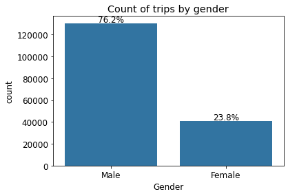

```python
#plot the count of trips for each gender

gender=df.member_gender.value_counts()
n_gender=gender.sum()
gender_order=gender.index
base_color=sb.color_palette()[0]
plt.rcParams['font.size'] = 12.0

sb.countplot(data=df, x='member_gender',order=gender_order,color=base_color)

plt.xlabel('Gender')
plt.title('Count of trips by gender')
    #print the proportion text on the bars of each gender
for i in range (gender.shape[0]):
    # Remember, gender contains the frequency of unique values in the `member_gender` column in decreasing order.
    count = gender[i]
    # Convert count into a percentage, and then into string
    precentage_string = '{:0.1f}%'.format(100*count/n_gender)
    # Print the string value on the bar.
    plt.text(i, count+1000, precentage_string, ha='center')

# we can remove the top and right axis using rcParams:
#plt.rcParams["axes.spines.right"] = False
#plt.rcParams["axes.spines.top"] = False;
```

we can see that about 76.2% user are male and 23.8% are female.

#### Q2- Which user type has the most trips?

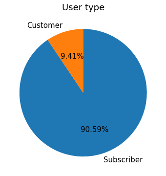

```python
#plot the user type precentage
# Show data in persentage for with 2 decimal point
plt.figure(figsize=(6,6))
plt.rcParams['font.size'] = 15.0
user=df.user_type.value_counts()
plt.pie(user,labels=user.index,startangle=90,counterclock=False,autopct = "%0.2f%%")
plt.title('User type');
```

The pie chart above showing the distribution of user type, there are more subscribers than customers.

#### Q3- Is it bike share for all trip?

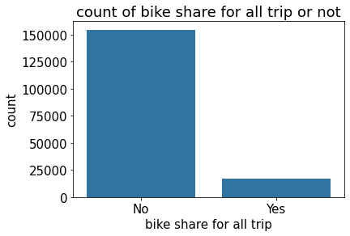

```python
#plot if bike share for all trip or not
b_order=df.bike_share_for_all_trip.value_counts()
sb.countplot(data=df, x='bike_share_for_all_trip',order=b_order.index,color=base_color)
plt.xlabel('bike share for all trip')
plt.title('count of bike share for all trip or not');
```

From the distribution above, it seems that most of users did't use bike share for all of their trips.

#### Q4- What are the most popular/used start or end station?

###### start station

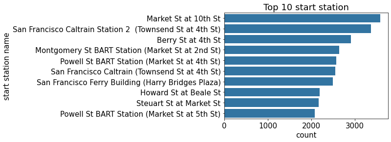

```python
#we can see the top 10 start station name in this plot
start_station=df.start_station_name.value_counts()[:10]
sb.countplot(data=df, y='start_station_name',order=start_station.index,color=base_color);
plt.ylabel('start station name')
plt.title('Top 10 start station');
```

##### End station

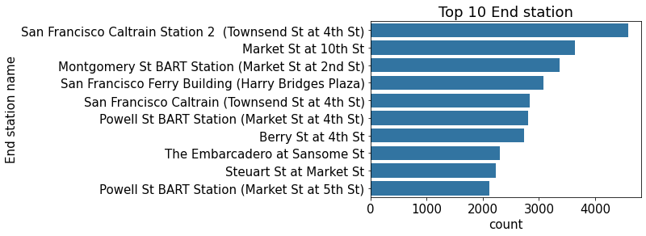

```python
#we can see the top 10 End station name in this plot
End_station=df.end_station_name.value_counts()[:10]
sb.countplot(data=df, y='end_station_name',order=End_station.index,color=base_color);
plt.ylabel('End station name')
plt.title('Top 10 End station');
```

we can see the most popular stations from the above charts.

#### Q5- How long does the average trip take?

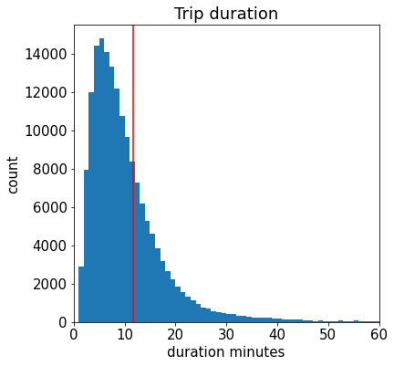

```python
#histogram of trip duration in minutes limited to 60 minutes(1 Hour)
plt.figure(figsize=(6,6))
plt.rcParams['font.size'] = 15.0
trip_mean=df.duration_minutes.mean()
# Create bins with step size 1
bins = np.arange(0, df['duration_minutes'].max()+1, 1)
plt.xticks(np.arange(0,df['duration_minutes'].max()+10,10))
plt.hist(data = df, x = 'duration_minutes', bins = bins)
plt.axvline(trip_mean, color='red', label='Avg trip Duration')
#Using xlim, Set the upper and lower bounds of the bins that are displayed in the plot
plt.xlim(0,60)
plt.title('Trip duration')
plt.xlabel('duration minutes')
plt.ylabel('count');
```

```python
#to see the duration minutes which are greater than 60
df[df['duration_minutes']>60]
```

|  | start_time | end_time | start_station_name | end_station_name | user_type | member_gender | bike_share_for_all_trip | duration_minutes |
| --- | --- | --- | --- | --- | --- | --- | --- | --- |
| 0 | 2019-02-28 17:32:10.145 | 2019-03-01 08:01:55.975 | Montgomery St BART Station (Market St at 2nd St) | Commercial St at Montgomery St | Customer | Male | No | 869.750000 |
| 2 | 2019-02-28 12:13:13.218 | 2019-03-01 05:24:08.146 | Market St at Dolores St | Powell St BART Station (Market St at 4th St) | Customer | Male | No | 1030.900000 |
| 91 | 2019-02-28 21:41:16.900 | 2019-02-28 23:14:58.186 | Channing Way at Shattuck Ave | Shattuck Ave at Hearst Ave | Subscriber | Female | No | 93.683333 |
| 163 | 2019-02-28 21:22:51.632 | 2019-02-28 22:46:10.114 | The Embarcadero at Sansome St | Steuart St at Market St | Customer | Male | No | 83.300000 |
| 199 | 2019-02-28 18:23:19.035 | 2019-02-28 22:35:22.294 | The Embarcadero at Bryant St | Myrtle St at Polk St | Subscriber | Male | No | 252.050000 |
| ... | ... | ... | ... | ... | ... | ... | ... | ... |
| 179948 | 2019-02-01 11:27:49.004 | 2019-02-01 12:31:36.396 | Emeryville Public Market | Emeryville Public Market | Customer | Female | No | 63.783333 |
| 180894 | 2019-02-01 08:39:00.243 | 2019-02-01 09:58:50.831 | 17th St at Dolores St | Montgomery St BART Station (Market St at 2nd St) | Subscriber | Male | No | 79.833333 |
| 181707 | 2019-02-01 07:58:36.852 | 2019-02-01 09:04:57.425 | Valencia St at Cesar Chavez St | San Francisco Ferry Building (Harry Bridges Pl... | Subscriber | Female | Yes | 66.333333 |
| 182411 | 2019-02-01 04:38:43.601 | 2019-02-01 08:25:33.493 | Sanchez St at 17th St | 7th St at Brannan St | Subscriber | Male | Yes | 226.816667 |
| 183326 | 2019-02-01 01:02:55.168 | 2019-02-01 02:38:09.002 | Raymond Kimbell Playground | Raymond Kimbell Playground | Subscriber | Male | No | 95.216667 |

1312 rows × 8 columns

since there is only few rows where the duration minutes greater than 60 it seems fine to drop them.

```python
#drop the rows where the duration minutes greater than 60
df.drop(df[df['duration_minutes'] > 60].index, inplace=True)
```

```python
df.duration_minutes.describe()
```

```
count    169993.000000
mean         10.284751
std           7.361724
min           1.016667
25%           5.350000
50%           8.433333
75%          12.966667
max          59.916667
Name: duration_minutes, dtype: float64
```

#### Q6- When are most trips taken in terms of time of day or day of the week?

```python
# Create new columns[start_day, Hour] from the start_time column for analysis.
df['start_day'] = df['start_time'].dt.day_name()
df['hour'] = df['start_time'].dt.hour
```

```python
#pay attention to hour column it starts from 0 untill 23
df.hour.value_counts().index
```

```
Int64Index([17,  8, 18,  9, 16,  7, 19, 15, 12, 13, 10, 14, 11, 20, 21,  6, 22,
            23,  5,  0,  1,  2,  4,  3],
           dtype='int64')
```

##### Time Of day

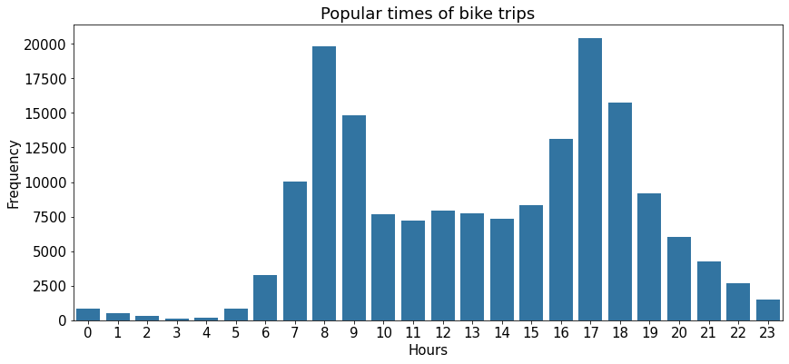

```python
# plot bike trip based on Hours
plt.figure(figsize=(14,6))

hour_order = np.arange(0,24)
sb.countplot(data=df, x='hour', order=hour_order, color=base_color)
plt.title('Popular times of bike trips')
plt.xlabel('Hours')
plt.ylabel('Frequency');
```

Based on the chart above, it seems that bicycle services is higher on peak hours.

##### day of the week

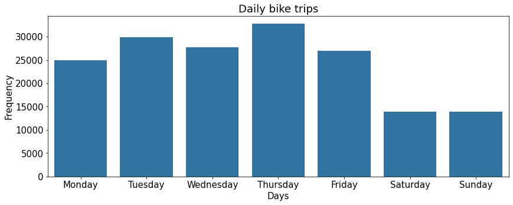

```python
#plot bike trips based on days
plt.figure(figsize=(14,5))

#According to international standard ISO 8601, Monday is the first day of the week.
#In the middle East : ["Saturday","Sunday","Monday","Tuesday","Wednesday","Thursday","Friday"]
days_order =["Monday","Tuesday","Wednesday","Thursday","Friday","Saturday","Sunday"]
sb.countplot(data=df, x='start_day', order=days_order, color=base_color);
plt.title('Daily bike trips')
plt.xlabel('Days')
plt.ylabel('Frequency');
```

The chart above showing that weekdays is busier than weekends.

### Of the features you investigated, were there any unusual distributions? Did you perform any operations on the data to tidy, adjust, or change the form of the data? If so, why did you do this?

There is some problem to this Ford GoBike data, such as:

- Quality issues for many columns, such as the dtype is not suitable with it's data.
- We have to add some column(hour, day) from start time column for analysis.
- The trip duration were in secounds and i converted them to minutes to be easier to understand.
- When plotting out the trip duration, it was messy so i used xlim() to zoom in to closer range where most trip durations fell. Then i droped the rows which had duration minutes greater than the limited range.

## Bivariate Exploration

#### Q7- How long does the average trip duration take for each user type?

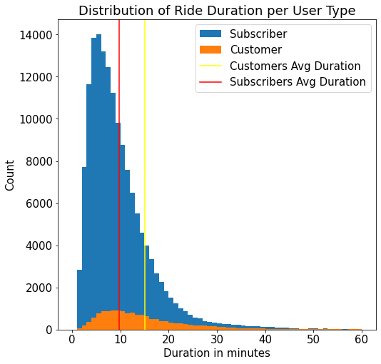

```python
#plotting distribution of ride durations per user type
plt.figure(figsize=(8,8))

customer_mean = df.query('user_type == "Customer"')['duration_minutes'].mean()
Subscriber_mean=cust_mean = df.query('user_type == "Subscriber"')['duration_minutes'].mean()

#Subscriber
subs_bins= np.arange(0,61,1)
subs_d=df.query('user_type == "Subscriber"')['duration_minutes']
plt.hist(x= subs_d, bins = subs_bins, label = 'Subscriber')
#Customer
cust_bins=np.arange(0,61,1)
cust_d=df.query('user_type == "Customer"')['duration_minutes']
plt.hist(x= cust_d, bins = cust_bins, label = 'Customer')

plt.title('Distribution of Ride Duration per User Type')
plt.xlabel('Duration in minutes')
plt.ylabel('Count')

plt.axvline(customer_mean, color='yellow', label='Customers Avg Duration')
plt.axvline(Subscriber_mean, color='red', label='Subscribers Avg Duration')
plt.legend(loc='upper right')
plt.show();
```

we can see from the above histogram that cutomers average trip duration is almost 15 minutes and the subscribers average trip duration is almost 10 minutes.

##### Trip duration for each user type

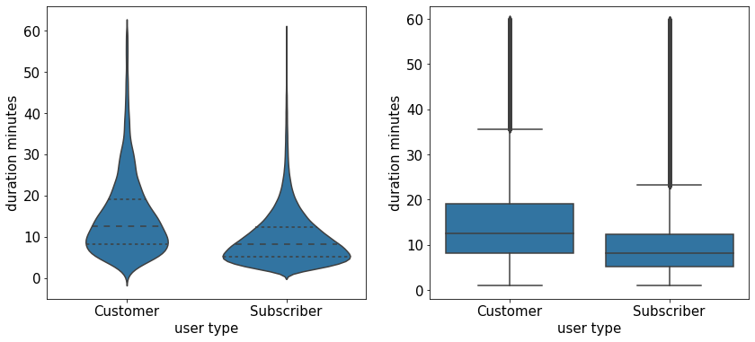

```python
#subplots of trip duration for each user type
#violin plot
plt.figure(figsize=(14,6))
plt.subplot(1,2,1)
sb.violinplot(data=df,x='user_type',y='duration_minutes',color=base_color, inner='quartiles')
plt.xlabel('user type')
plt.ylabel('duration minutes');
#box plot
plt.subplot(1,2,2)
sb.boxplot(data=df,x='user_type',y='duration_minutes',color=base_color)
plt.xlabel('user type')
plt.ylabel('duration minutes');
```

we can see from the violin and box plots above that customers take longer bike trips than subscribers.

##### Q8- Who is more consumption of daily trips?Customers or subscripers?

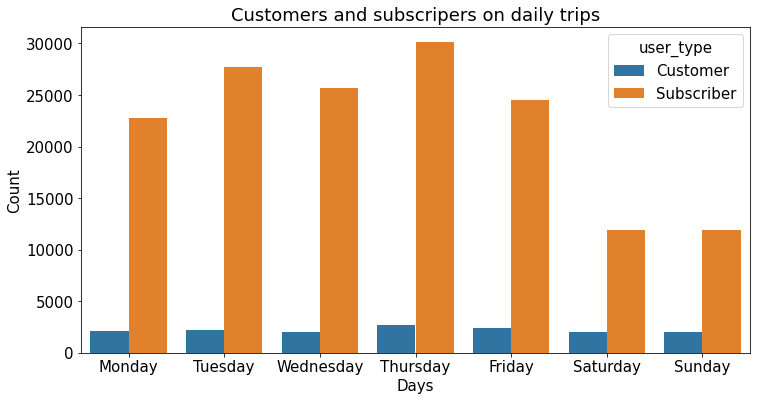

```python
plt.figure(figsize=(12,6))
sb.countplot(data=df, x='start_day', hue='user_type',order=days_order)
plt.title('Customers and subscripers on daily trips')
plt.xlabel('Days')
plt.ylabel('Count');
```

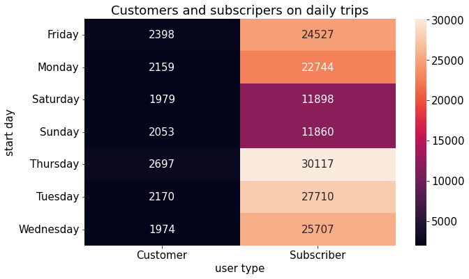

```python
#heatmap
plt.figure(figsize=(10,6))
u_counts=df.groupby(['start_day','user_type']).size()
u_counts=u_counts.reset_index(name='count')
u_counts=u_counts.pivot(index='start_day',columns='user_type',values='count')
sb.heatmap(u_counts, annot = True, fmt = 'd')
plt.title('Customers and subscripers on daily trips')
plt.xlabel('user type')
plt.ylabel('start day');
```

it seems that subscripers has the most trips on daily usage than customers.

##### we can see through this FaceGrid the distribution of duration minutes for each day.

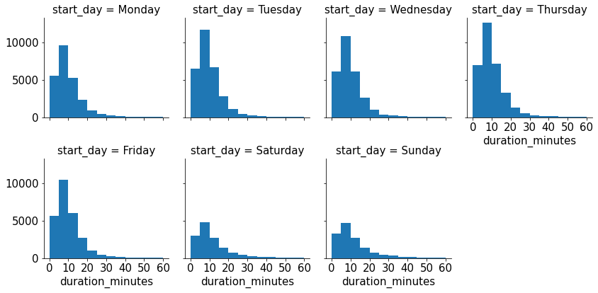

```python
bin_edges = np.arange(0, 61, 5)
a= sb.FacetGrid(data = df, col = 'start_day', col_wrap=4,col_order=days_order)
plt.xticks(np.arange(0, 61, 10))
a.map(plt.hist, 'duration_minutes', bins = bin_edges);
```

### Talk about some of the relationships you observed in this part of the investigation. How did the features of interest vary with other features in the dataset?

> Customers tends to have longer trip durations than Subscribers, but the Subscribers usage is higher than customer usage.

### Did you observe any interesting relationships between the other features (not the main features of interest)?

> Most Subscribers use the service at peak hours.

## Multivariate Exploration

##### Q9- Do customers take longer bike trips than subscribers?

```python
#function for the next boxplots
def box_plot(data,x,y,hue,order=None):
    plt.figure(figsize=(14,6))
    sb.boxplot(data=data,x=x, y=y,hue=hue,order=order)
    plt.legend(loc='upper right');
```

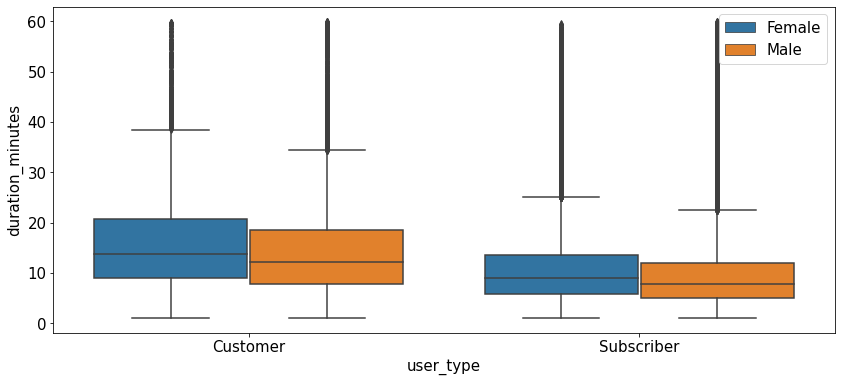

```python
##### Comparison of trip durations between customers and subscribers for each gender
box_plot(df,df.user_type,df.duration_minutes,df.member_gender)
```

##### Q10 Do customers take longer bike trips on average than subscribers throughout the day?

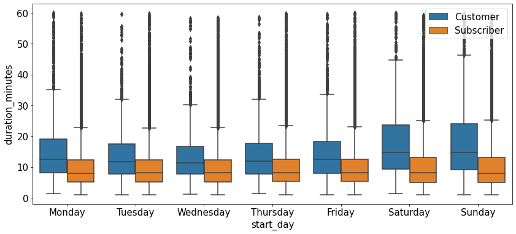

```python
#distribution of trip durations per user type on each day of week
box_plot(df,df.start_day,df.duration_minutes,df.user_type,days_order)
```

The above box plot affirms that customers take longer bike trips on average regardless of the day of week

### Were there any interesting or surprising interactions between features?

> There is nothing to be suprised about. but it will be interesting to know the different patterns of bike usage for other months, cause in this dataset there is only one month(february).

```python
#save clean dataframe
df_clean_data=df.to_csv('df_clean.csv')
df_clean=pd.read_csv('df_clean.csv')
df_clean.head()
```

|  | Unnamed: 0 | start_time | end_time | start_station_name | end_station_name | user_type | member_gender | bike_share_for_all_trip | duration_minutes | start_day | hour |
| --- | --- | --- | --- | --- | --- | --- | --- | --- | --- | --- | --- |
| 0 | 4 | 2019-02-28 23:54:18.549 | 2019-03-01 00:20:44.074 | Frank H Ogawa Plaza | 10th Ave at E 15th St | Subscriber | Male | Yes | 26.416667 | Thursday | 23 |
| 1 | 5 | 2019-02-28 23:49:58.632 | 2019-03-01 00:19:51.760 | 4th St at Mission Bay Blvd S | Broadway at Kearny | Subscriber | Male | No | 29.883333 | Thursday | 23 |
| 2 | 6 | 2019-02-28 23:55:35.104 | 2019-03-01 00:14:42.588 | Palm St at Willow St | San Jose Diridon Station | Subscriber | Female | No | 19.116667 | Thursday | 23 |
| 3 | 7 | 2019-02-28 23:41:06.766 | 2019-03-01 00:08:02.756 | Washington St at Kearny St | Valencia St at 21st St | Subscriber | Male | No | 26.916667 | Thursday | 23 |
| 4 | 9 | 2019-02-28 23:49:47.699 | 2019-03-01 00:07:17.025 | Post St at Kearny St | Mission Playground | Subscriber | Male | No | 17.483333 | Thursday | 23 |

## Conclusions

The following are the main findings from the above exploratory analysis using univariate, bivariate, and multivariate visualization for the Ford Gobike dataset.

- There are more male members in Ford GoBike than females. almost 76.2% of the users are male, and 23.8% are females.
- The majority of members who participate in the Ford GoBike trips were subscribers not customers.
- Most of GoBikes users did't use bike share for all of their trips.
- When analyzing the day of weeks, bike trip patterns were different on weekdays than on weekends. There is higher frequency of bike trips on weekdays than on weekends, and most of the trips started on Tuesday and Thursday.
- When analyzing the time of bike trips, GoBike users are most frequent during the peak hours.
- Customers took longer time to complete the trip than subscribers.
- Regardless of the user type, male members appear to complete the trip faster than females.